### Histogram of the total number of steps taken each day after missing values are imputed

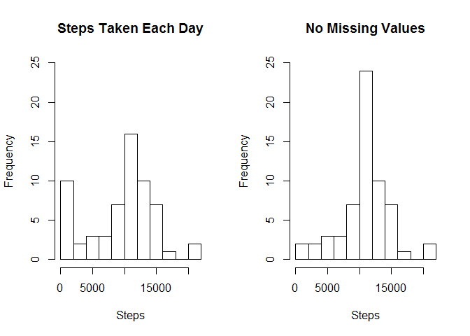

```r
# tsd.new = total steps by day using ac.new
tsd.new <- with(ac.new, tapply(steps, date, sum, na.rm = T))

par(mfrow = c(1, 2))
hist(tsd, main = "Steps Taken Each Day", xlab = "Steps", ylim = c(0,25), breaks = 10)
hist(tsd.new, main = "No Missing Values", xlab = "Steps", ylim = c(0,25), breaks = 10)
```

The new histogram looks more normally distributed than the orginal one because of the filling of the missing values using average steps of each interval. The main changes happened in lower number of steps and middle number of steps. The former one decreased and the latter one increased largely. Others remain unchanged, because there were no missing values in there.

```r
meantsd.new <- mean(tsd.new)
meditsd.new <- median(tsd.new)

#Mean of the total number of steps taken each day before and after the filling of missing values, and the percentage changes:
meantsd; meantsd.new; (meantsd.new - meantsd) / meantsd
```

```
## [1] 9354.23
```

```
## [1] 10765.64
```

```
## [1] 0.1508847
```

```r
#Median of total number of steps taken each day before and after the filling of missing values, and the percentage changes:
meditsd; meditsd.new; (meditsd.new - meditsd) / meditsd
```

```
## [1] 10395
```

```
## [1] 10762
```

```
## [1] 0.03530544
```

Both mean and median number of steps increased, but mean number of steps increased more apparently, maybe because the mean was more sensitive to extreme values.

## Are there differences in activity patterns between weekdays and weekends?

### Panel plot comparing the average number of steps taken per 5-minute interval across weekdays and weekends

first, create two new levels:

```r
ac.new$date <- as.Date(ac.new$date)
ac.new$type <- weekdays(ac.new$date)
weekdays <- c("Monday", "Tuesday", "Wednesday", "Thursday", "Friday")
weekends <- c("Saturday", "Sunday")
ac.new$type[ac.new$type %in% weekdays] <- "weekday"
ac.new$type[ac.new$type %in% weekends] <- "weekend"
ac.new$type <- as.factor(ac.new$type)
```

Second, calculate average number of steps taken for each interval, both on weekdays and weekends.

```r
#wd = weekdays, wk = weekends
wd <- ac.new[ac.new$type == "weekday",]
wk <- ac.new[ac.new$type == "weekend",]

#wd.msi = mean steps for each interval on weekdays, wk.msi = mean stpes for each interval on weekends.
wd.msi <- as.data.frame(with(wd, tapply(steps, interval, mean)))
wk.msi <- as.data.frame(with(wk, tapply(steps, interval, mean)))

names(wd.msi) <- "steps"
names(wk.msi) <- "steps"

wd.msi$interval <- rownames(wd.msi)
wk.msi$interval <- rownames(wk.msi)

wd.msi$type <- "weekday"
wk.msi$type <- "weekend"

msi.new <- rbind(wd.msi, wk.msi)
msi.new$interval <- as.numeric(msi.new$interval)
```

Third, make plots:

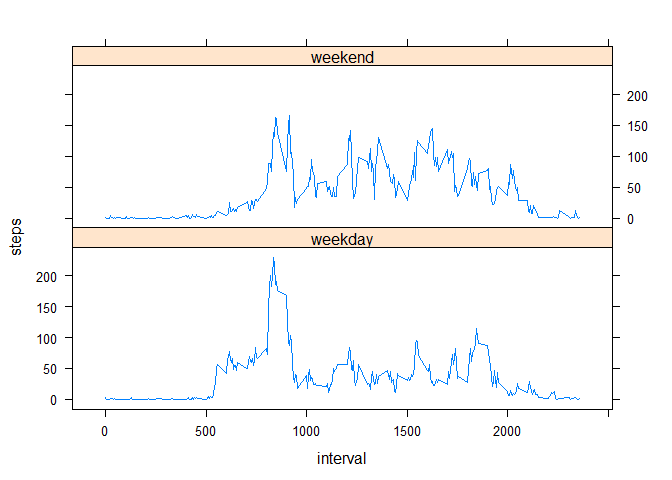

```r
library(lattice)
xyplot(steps ~ interval | type, data = msi.new, type = "l", layout = c(1, 2))
```